# Lecture 4

27 January 2019

## Structure

1. Distance recap
2. Clustering introduction
3. K-means
4. Hierarchical method
5. DBSCAN

## Literature

- [Machine Learning with R](https://www.amazon.com/Machine-Learning-R-Brett-Lantz/dp/1782162143)
- [R for Marketing Research and Analytics](https://www.amazon.com/Marketing-Research-Analytics-Use/dp/3319144359)

## Distance recap

- definition
- Euclidean
- mixed data
- Gower

## Clustering introduction

## About clustering

- a very frequent step in analyses
  - cluster your customers
  - cluster your products
- unsupervised learning
  - no learning the rules
    - no predictions
  - classify without training
- objective: internally homogenous and externally heterogenous groups
- highly sensitive to distance specification
  - scalling!

## Example

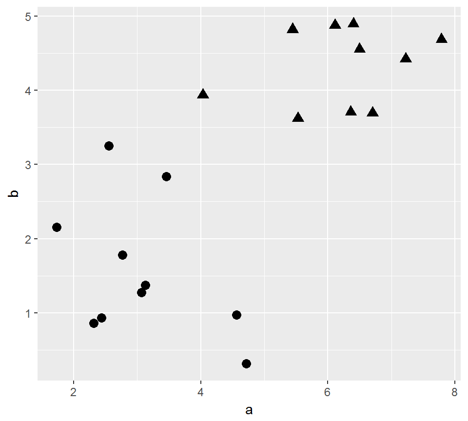

## Kmeans way

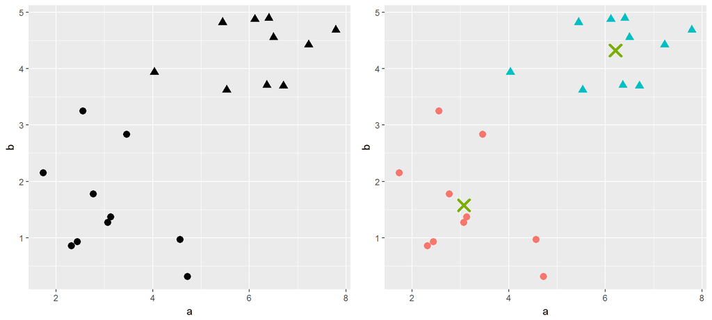

## Solving practical problems

- **!!! customer segmentation !!!**
  - RFV segmentations
    - recency - frequency - value
- product substitutions
  - similar products bought in different baskets by same customers
  - how to define the distance between butter and milk?
- basket labelling
  - re-supply, spontaneous, daily
  - when are what types of baskets happening?
    - special offers

## Kmeans algorithm

## Overview

- segment data into **K** clusters
- greedy: will cluster all observations
  - outliers, bad data
  - hard clustering
- **centers**
  - centroids of the clusters
  - mean in all dimensions

## Algorithm

1. choose **K** observations randomly
2. update **centers**
   - **for** each **observation**:
     - calculate **distance** to each **center**
     - assign observation to the closest **center** = clusters
   - if no observation changes mebership
     - **break**
3. calculate the **centroid** of each cluster
   - **centroids** will be assigned as new **centers**
   - repeat from 2.

## First iteration

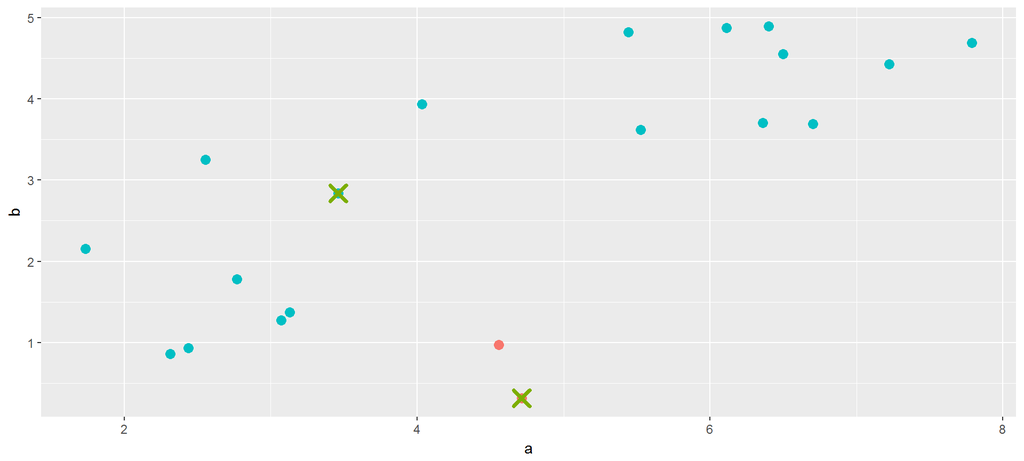

## All iterations

[video not shown]

## Last iteration

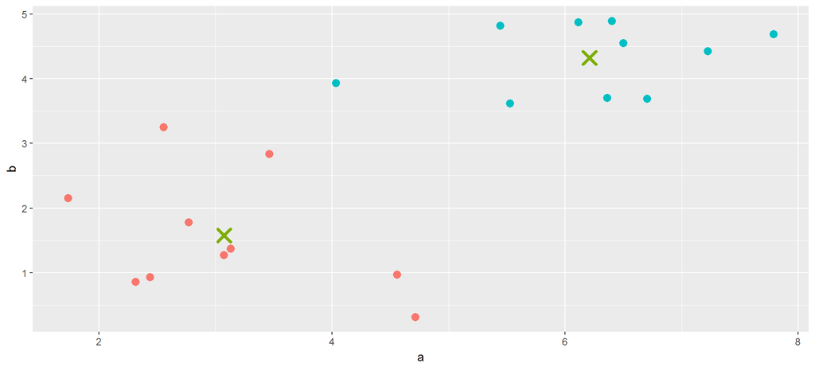

## Summary

- classical implementation- stats::kmeans
- forget the clusters, find the appropriate centers
- algorithm assumptions:
  - spherical data
  - constant variance across variables
  - similar number of members
- greedy algorithm
  - initialization problem
- argument **K** needs to be optimised
  - usually via elbow method (→ seminar)

## Hierarchical method

## Key words

- dendogram
- divisive or agglomerative
- [linkage methods](http://uc-r.github.io/hc_clustering#algorithms)
  - link to the picture on the next slide

## Linkage graphically

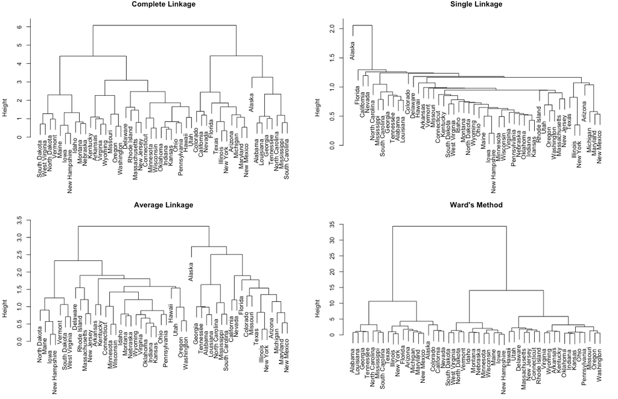

## Overview

- segment data into a hierarchy
  - clusters will be defined later
- greedy: will cluster all observations
  - outliers should be visually distinguishable
- assuming points always closer to **own label** than to **other label** observations

## Algorithm - agglomerative

1. Find the two closest points
   - merge them into a cluster
2. Repeat until only one cluster exists
   - cluster distance based on linkage method
- for divisive clustering
  - start with one cluster
  - run kMeans like routine

## First merge

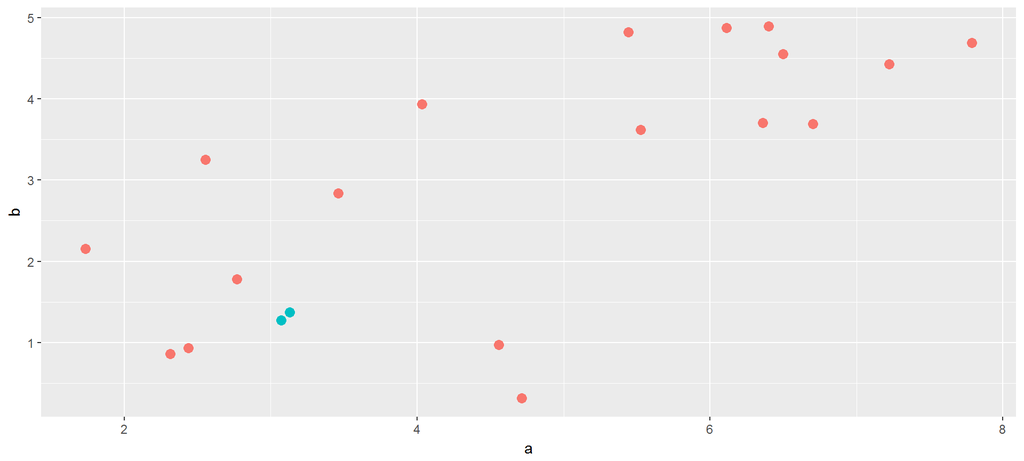

## All merges

[video not shown]

## Dendogram

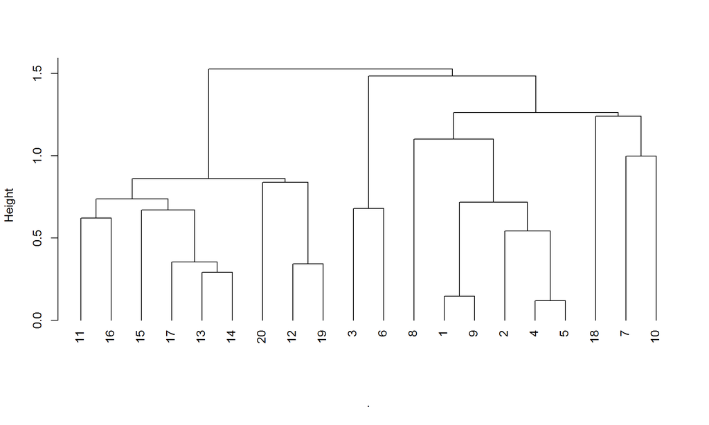

## Summary

- classical implementation- stats::hclust
- merge the points one by one into groups
- greedy algorithm
- where to split?
  - usually via at maximum vertical distance (→ seminar)
  - or on the number of clusters you need

## DBSCAN

## Overview

- going through the dataset looking for large density groups
  - density based on parameters
    - **eps** = distance
    - **minPoints** = number of points
  - check if there is at least **minPoints** in **eps** around chosen point
- core, border, outlier points
  - core = point with at least **minPoints** around
  - border = point at least **eps** far from core point
    - less than **minPoints** around
  - outlier = point further than **eps** to any core point
    - less than **minPoints** around

## Algorithm

1. Choose the first **point**
   - mark it as **visited**
   - find **nearby points** (closer than **eps**) and count them
     - ignore if less than **minPoints** (outlier)
   - else **label chosen point** and **all nearby points** as **cluster_x**
2. For each **unvisited point** in **cluster_x**
   - find **nearby points** and count them
     - if less than **minPoints**
       - **border point**
     - else assign **nearby points** to **cluster_x**
3. **Break** when all **points visited**

## First iteration

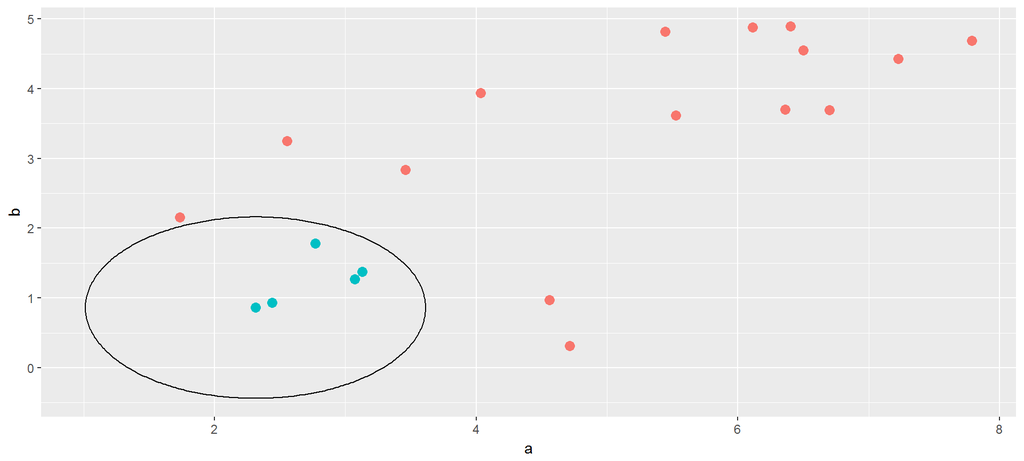

## All iterations

[video not shown]

## Summary

- classical implementation- dbscan::dbscan
- more [flexible](http://scikit-learn.org/stable/modules/clustering.html) than kMeans or hclust
- need to choose the parameters
  - eps estimated using dbscan::kNNdist
  - minPoints based on subject matter
- deterministic, but!
  - re-arranging the data can change the clusters
  - some point labels based on “who reaches them first”
    - therefore can be problematic for smaller datasets